# Homosexual Prejudice

K.Harris

22/05/2021

# Data origin

The data used in this project (homosexual_prejudice_data.csv) was obtained from the Open Science Frame work and comes from study 1 in De Figueiredo & Pereira’s (2021) research titled “The effect of gender and male distinctiveness threat on prejudice against homosexuals”. The overall aim of the research was to show that gender differences in prejudice towards homosexuals are due to males striving more for positive distinctiveness between the genders and consequently using prejudice towards homosexuals as a defence against their potential threat to this.

# Research question

The aim of the following project is to provide a visualisation to answer the above hypothesis for study 1 by showing the mean scores of both the male and female participants in relation to their prejudice against gay men and lesbians.

# Repository

The code, plots and data files used to create this Rmd page can be found [here](https://github.com/KierHarris/homosexual_prejudice_project)

# Preparing R

```r
# you may need to set the working directory to where the data file is saved
```

```r
#you may need to install the following packages
#install.packages("here")
#install.packages("dplyr")
#install.packages("tidyverse")
#install.packages("wesanderson")

#load packages
library(here)
library(dplyr)
library(tidyverse)
library(wesanderson)
```

# Data preperation

```r
# Load homosexual prejudice data
rawdata<-read.csv(here("data","homosexual_prejudice_data.csv"))

#check data
head(rawdata)
```

```
##   ï..gay.lesbian gender prej1 prej2 prej3 prej4 prej5 prej6 prej7 prej8 prej9
## 1              0      0     2     3     4     4     5     3     3     1     5
## 2              0      0     3     3     3     1     5     2     3     3     2
## 3              0      1     1     1     1     1     1     1     1     1     1
## 4              0      1     1     1     1     1     1     1     1     1     1
## 5              0      0     1     1     1     2     1     1     1     1     1
## 6              0      0     1     1     1     1     1     1     1     1     1
##   prej10 age maritalstatus religion socialstatus sexuality sexualinvo
## 1      5  21             1        1            3         1          2
## 2      2  31             1        1            2         1          2
## 3      1  19             1        1            2         1          2
## 4      2  30             1        4            2         1          2
## 5      1  23             1        1            1         1          2
## 6      1  18             1        4            1         1          2
##   attraction prejtotal
## 1          1         4
## 2          1         3
## 3          1         1
## 4          2         1
## 5          1         1
## 6          1         1
```

```r
#remove latter participant rows where sexuality scores are >1 as these participants are not heterosexual and create new data file
df<-rawdata[-c(233:278), ]

#use factor to label gender values from 0 and 1 to female and male
gender<-factor(df$gender, levels=c(0,1), labels= c("female", "male"))

#use factor to label experimental condition values from 0 and 1 to lesbians and gay men
condition<-factor(df$ï..gay.lesbian, levels=c(0,1), labels=c("lesbians", "gay men"))

#assign appropriate names to variables
prejudice<-df$prejtotal
```

# Visualisation

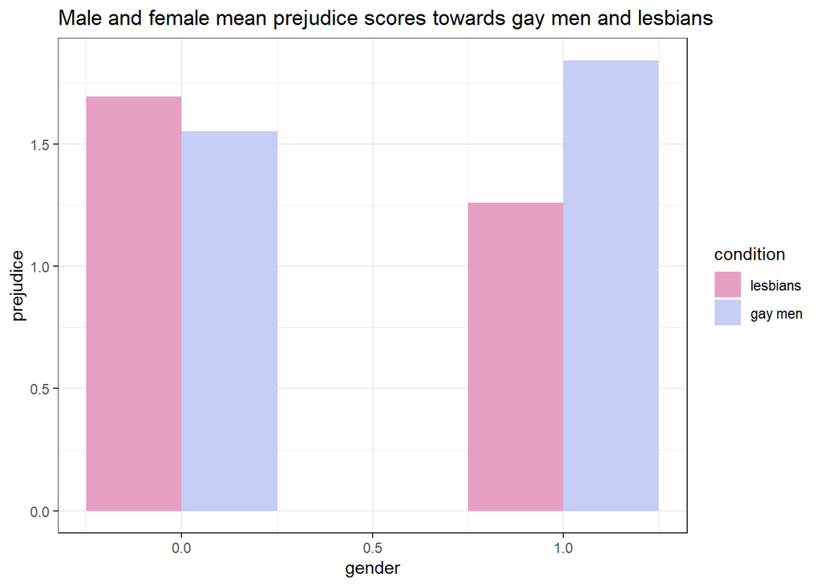

```r
#assign a name to the plot and let ggplot know which data frame to use
bar<-ggplot(df,
# use fill to assign colours to the bars depending on which condition the participant is in and set x and y axis
                aes(fill=condition, x=gender, y=prejudice))+
# use geom_bar to create a bar chart, dodge to separate males and females by the condition they were in to create a grouped bar chart and mean to ensure the mean prejudice scores are included
                geom_bar(position = "dodge",stat = "summary", fun="mean", width=0.5)+
#create the bar chart title
                ggtitle("Male and female mean prejudice scores towards gay men and lesbians")+
#assign a colour scheme for the bars
                scale_fill_manual(values=wes_palette(n=3, name = "GrandBudapest2"))+
#set a black and white theme for the axis and back grid
                theme_bw()
#present bar chart
bar
```

# Summary

The visualisation shows that heterosexual males are distinctly more prejudice towards gay men than heterosexual females are as well as distinctly less prejudice towards lesbians. Heterosexual female’s prejudice towards gay men and lesbians is relatively similar. Regarding the hypothesis, the visualisation shows that the researchers were correct in suggesting that heterosexual males are more prejudice towards gay men than heterosexual females but incorrect in saying that they are more prejudice to homosexuals in general. This is because male’s prejudice scores towards lesbians were much lower than female’s prejudice scores towards both gay men and lesbians.

Since the raw data from study 1 included data that may impact the participants attitudes towards homosexuality e.g., religion which largely associated with unacceptance and negative attitudes towards homosexuality (Whitley Jr, 2009). A follow up visualisation could be useful to see if there is a difference in participants prejudice scores towards gay men and lesbians when these factors are controlled for.

# References

De Figueiredo, D., & Pereira, C. (2021). *Gender, male distinctiveness threat and prejudice against homosexuals*. Retrieved on 15th May 2021, from https://osf.io/gsxpe/

Whitley Jr, B. E. (2009). Religiosity and attitudes toward lesbians and gay men: A meta-analysis. *International Journal for the Psychology of Religion*, 19(1), 21-38. doi.org/10.1080/10508610802471104